# Indonesian Bot Army

## List of Accounts

- `favorite_count` = sum of likes received for posts
- `retweet_count` = sum of retweets received for posts
- `retweet_own_tweets_count` = sum of retweets received for posts that were created by the bots
- `favorite_own_tweets_count` = sum of likes received for posts that were created by the bots

|  | screen_name | followers_count | statuses_count | favorite_count | retweet_own_tweets_count | favorite_own_tweets_count | retweet_count | account_created_at | link | percent_english | percent_dutch | percent_indonesian | percent_german | percent_other | account_lang |
| --- | --- | --- | --- | --- | --- | --- | --- | --- | --- | --- | --- | --- | --- | --- | --- |
| 1 | janemargareth_ | 0 | 750 | 278 | 207 | 278 | 407 | 2020-07-16 09:47:38 | https://twitter.com/janemargareth_ |  | 100 |  |  |  | dutch |
| 2 | louisevans__ | 187 | 919 | 245 | 190 | 245 | 376 | 2020-06-14 08:19:56 | https://twitter.com/louisevans__ |  | 100 |  |  |  | dutch |
| 3 | maria7na | 1344 | 199 | 202 | 20 | 202 | 135 | 2020-07-26 17:24:30 | https://twitter.com/maria7na |  | 100 |  |  |  | dutch |
| 4 | solehudinr1 | 1004 | 139 | 175 | 36 | 175 | 85 | 2020-07-26 17:41:26 | https://twitter.com/solehudinr1 |  | 100 |  |  |  | dutch |
| 5 | eidelweisevali1 | 1021 | 151 | 173 | 26 | 173 | 77 | 2020-07-26 17:38:03 | https://twitter.com/eidelweisevali1 |  | 100 |  |  |  | dutch |
| 6 | kevindejong__ | 3 | 370 | 170 | 129 | 170 | 262 | 2020-09-16 15:18:40 | https://twitter.com/kevindejong__ |  | 100 |  |  |  | dutch |
| 7 | patrickrich__ | 0 | 360 | 161 | 119 | 161 | 237 | 2020-09-17 01:21:59 | https://twitter.com/patrickrich__ |  | 100 |  |  |  | dutch |
| 8 | rohmanuep | 862 | 171 | 157 | 23 | 157 | 118 | 2020-07-26 17:21:28 | https://twitter.com/rohmanuep |  | 100 |  |  |  | dutch |
| 9 | siti_kucing | 1040 | 135 | 151 | 21 | 151 | 60 | 2020-07-26 06:24:00 | https://twitter.com/siti_kucing |  | 100 |  |  |  | dutch |
| 10 | aaylachamberli1 | 405 | 189 | 148 | 60 | 148 | 79 | 2020-08-19 07:32:05 | https://twitter.com/aaylachamberli1 |  | 100 |  |  |  | dutch |

[output cut: 62 more lines]

## Accounts by language

The classification of accounts by language rely on the following logic:

If 66% of the tweets or more are in a given language, the account is classified to *predominantly* tweet in that language.

Example:

this account https://twitter.com/AngieKayman tweets are 96.95% classified by Twitter as German so I set `account_lang` to german.

Here I only classify accounts as English, Indonesian, Dutch and German because only for those languages are there enough tweets (the rest are probably misclassifations on behalf of Twitter anyway). If none of the accounts have above 66% tweets in one language, I code them as `mixed`. All others are classified as `other` (again probably missclassifacations but this number is small).

| account_lang | n |
| --- | --- |
| dutch | 72 |

## Number of Tweets

### Total Number

```
## [1] 13265
```

### Number of Tweets by language

| lang | n | perc |
| --- | --- | --- |
| nl | 13265 | 100 |

### Number of Tweets by location

| location | n | perc |
| --- | --- | --- |
| Papua | 996 | 58.59 |
| Mataram, Indonesia | 153 | 9.00 |
| Mojosari, Indonesia | 152 | 8.94 |
| Batu, Indonesia | 120 | 7.06 |
| Kota Makassar, Sulawesi Selata | 114 | 6.71 |
| Amsterdam, The Netherlands | 67 | 3.94 |
| Raja Ampat | 48 | 2.82 |
| Wamena | 23 | 1.35 |
| Teluk Bintuni | 13 | 0.76 |
| Bekasi Barat, Indonesia | 5 | 0.29 |
| Semarang, Jawa Tengah | 2 | 0.12 |
| Bojonegoro, Indonesia | 1 | 0.06 |
| Brisbane | 1 | 0.06 |
| Konawe Selatan, Sulawesi Tengg | 1 | 0.06 |
| Kupang, Kedah | 1 | 0.06 |
| London | 1 | 0.06 |
| London, England | 1 | 0.06 |
| Papua Barat, Indonesia | 1 | 0.06 |

### Number of Tweets by location (recoded by region)

| location | n | perc |
| --- | --- | --- |
| Indonesia | 1630 | 95.88 |
| London/Amsterdam/Birmingham | 69 | 4.06 |
| Australia | 1 | 0.06 |

## Number of Tweets created by the Accounts (excluding retweets)

### Total Number of Tweets created by the Accounts

```
## [1] 12317
```

### By language

| lang | n | perc |
| --- | --- | --- |
| nl | 12317 | 100 |

### Number of Tweets by location

| location | n | perc |
| --- | --- | --- |
| Papua | 996 | 65.61 |
| Mataram, Indonesia | 95 | 6.26 |
| Kota Makassar, Sulawesi Selata | 93 | 6.13 |
| Batu, Indonesia | 90 | 5.93 |
| Mojosari, Indonesia | 88 | 5.80 |
| Amsterdam, The Netherlands | 67 | 4.41 |
| Raja Ampat | 48 | 3.16 |
| Wamena | 23 | 1.52 |
| Teluk Bintuni | 13 | 0.86 |
| Bekasi Barat, Indonesia | 2 | 0.13 |
| Brisbane | 1 | 0.07 |
| London | 1 | 0.07 |
| Papua Barat, Indonesia | 1 | 0.07 |

### Number of Tweets by location (recoded by region)

| location | n | perc |
| --- | --- | --- |
| Indonesia | 1449 | 95.45 |
| London/Amsterdam/Birmingham | 68 | 4.48 |
| Australia | 1 | 0.07 |

## Number of Retweeted Tweets

### Total Number of Retweeted Tweets

```
## [1] 948
```

### By language

| lang | n | perc |
| --- | --- | --- |
| nl | 948 | 100 |

### Number of Tweets by location

| location | n | perc |
| --- | --- | --- |
| Mojosari, Indonesia | 64 | 35.16 |
| Mataram, Indonesia | 58 | 31.87 |
| Batu, Indonesia | 30 | 16.48 |
| Kota Makassar, Sulawesi Selata | 21 | 11.54 |
| Bekasi Barat, Indonesia | 3 | 1.65 |
| Semarang, Jawa Tengah | 2 | 1.10 |
| Bojonegoro, Indonesia | 1 | 0.55 |
| Konawe Selatan, Sulawesi Tengg | 1 | 0.55 |
| Kupang, Kedah | 1 | 0.55 |
| London, England | 1 | 0.55 |

### Number of Tweets by location (recoded by region)

| location | n | perc |
| --- | --- | --- |
| Indonesia | 181 | 99.45 |
| London/Amsterdam/Birmingham | 1 | 0.55 |

## Overall stats

### Number of Unique Accounts

```
## [1] 72
```

### Total received likes

```
## [1] 2663
```

### Total received retweets (only for posts created by bots)

```
## [1] 1271
```

## Over time graphs

### Number of Tweets over time

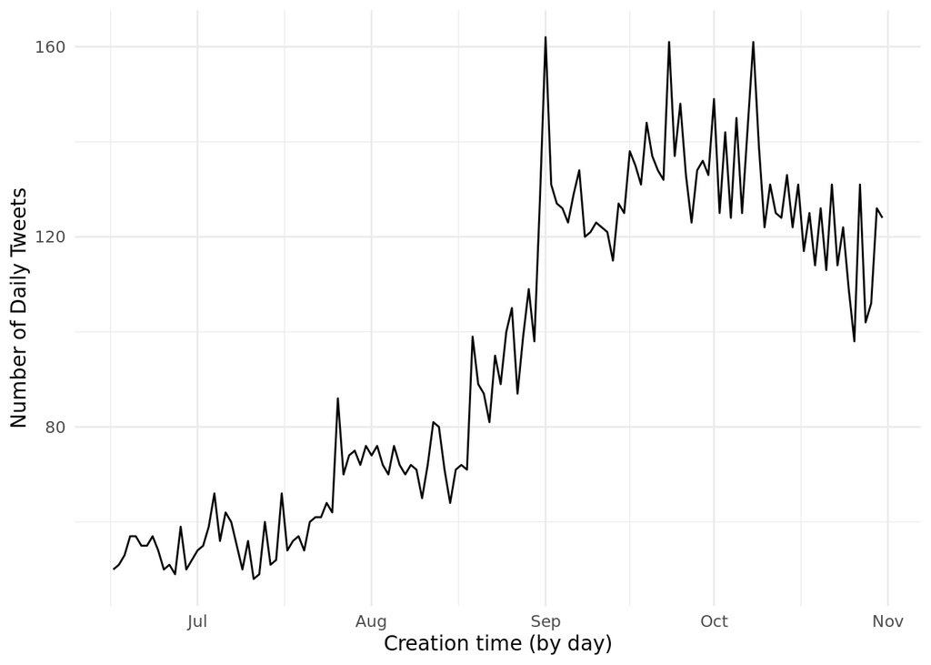

### Zoomed in

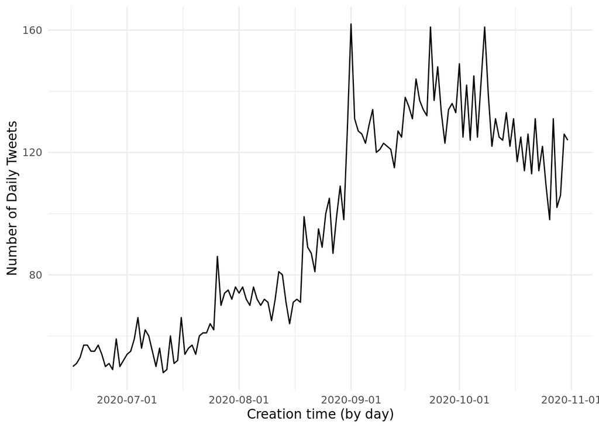

### Tweets by language over time

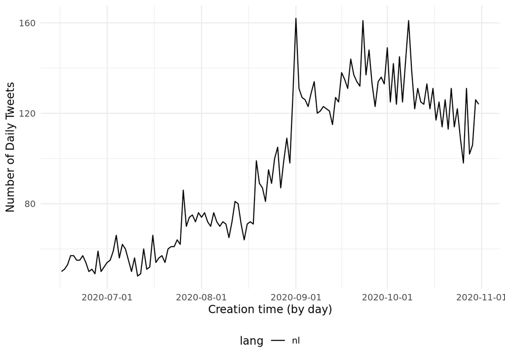

### Tweets by location over time

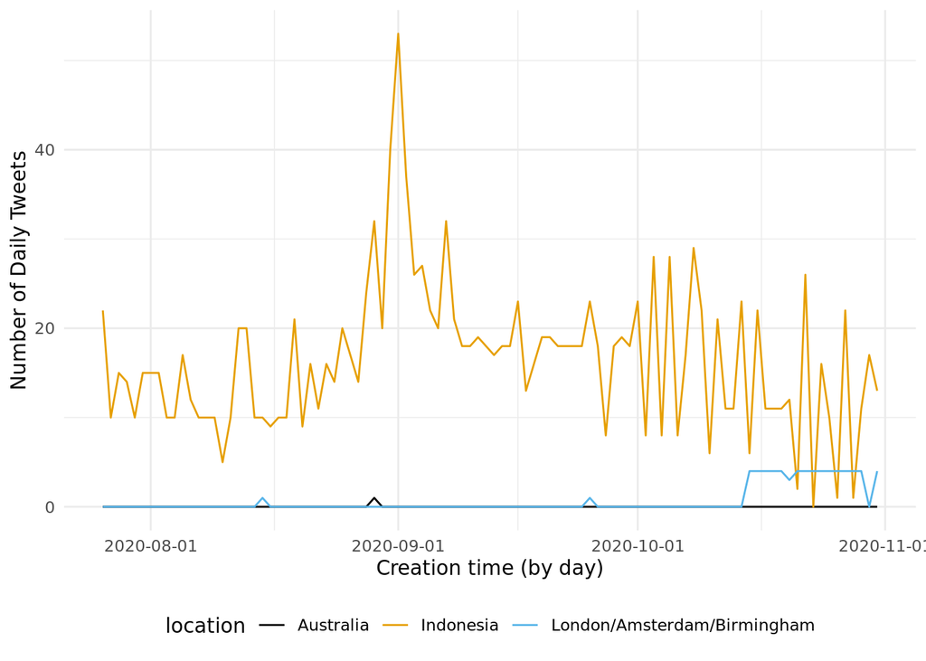

## Most common stats

### Most commonly used hashtags

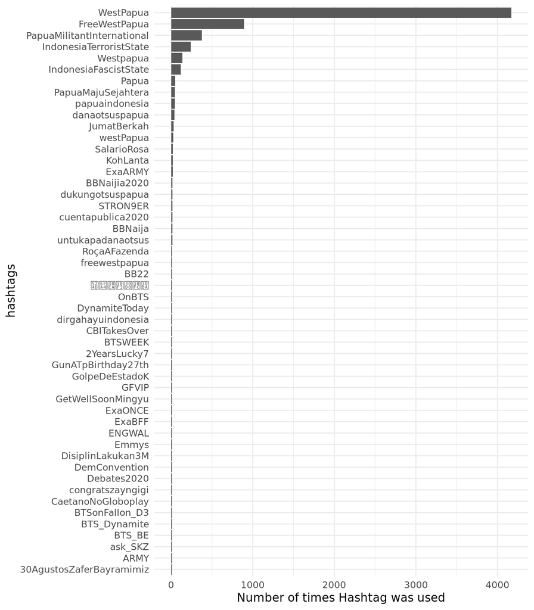

### Most common mentions

Black bars show accounts that are *not* in the initial bot sample.

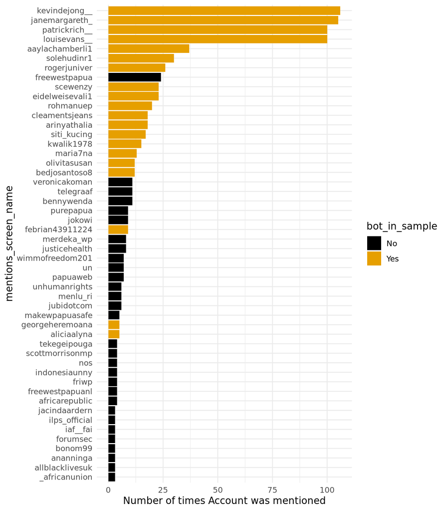

### Most common retweeted accounts

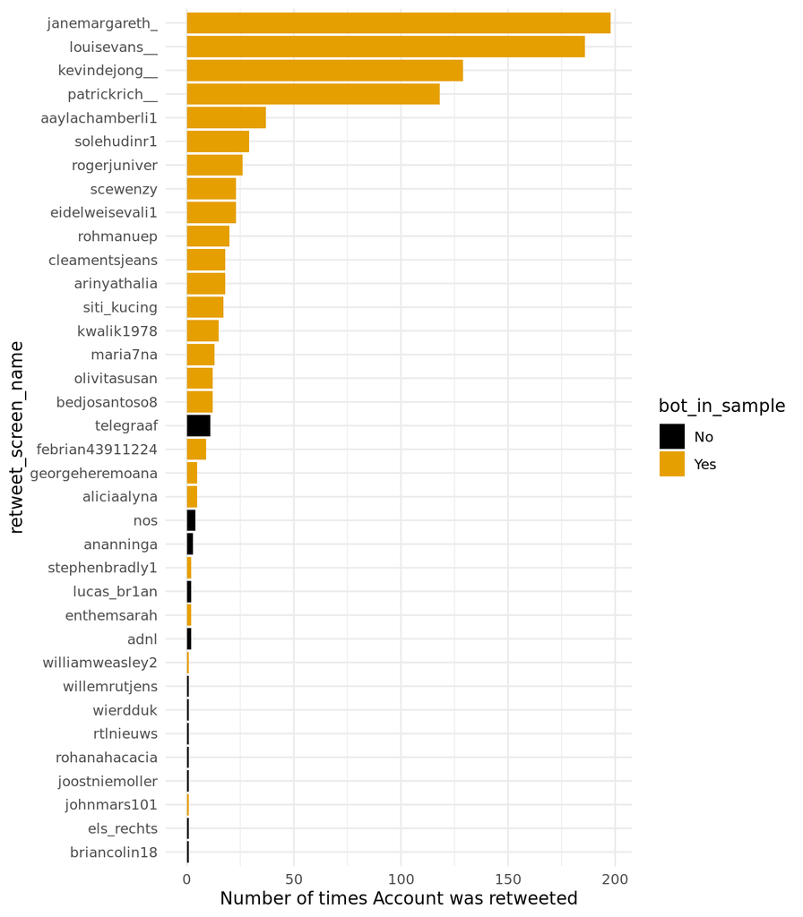

## Top 20s

### Top 20 Most liked posts

|  | link | screen_name | text | favorite_count | retweet_count |
| --- | --- | --- | --- | --- | --- |
| 1 | https://twitter.com/johnmars101/status/1294617833939308544 | johnmars101 | Tegen het einde van de verdeling van deze fondsen in 2021 zal de Indonesische regering alle partijen betrekken bij de bijzondere autonomie-evaluatie zodat de verdeling van de autonomiegelden echt op s… | 46 | 210 |
| 2 | https://twitter.com/olivitasusan/status/1320647203317190657 | olivitasusan | Otsus heeft veel voordelen opgeleverd voor de voortgang van Papua, het speciale autonomiebeleid is erg goed, waar Papoea's altijd voorrang krijgen op alle gebieden #Papua #papuaindonesia #PapuaMajuSej… | 17 | 6 |
| 3 | https://twitter.com/febrian43911224/status/1318711979708608512 | febrian43911224 | bijzondere autonomie moet worden geëvalueerd en voortgezet #Papua #papuaindonesia #PapuaMajuSejahtera #danaotsuspapua #dukungotsuspapua #untukapadanaotsus #otsuspapua https://t.co/OZbhTJFzMD | 13 | 6 |
| 4 | https://twitter.com/georgeheremoana/status/1318814948491812866 | georgeheremoana | laten we de voortzetting van Papua steunen voor het welzijn #Papua #papuaindonesia #PapuaMajuSejahtera #danaotsuspapua #dukungotsuspapua #untukapadanaotsus #otsuspapua https://t.co/t9XtdAktnR | 11 | 5 |
| 5 | https://twitter.com/maria7na/status/1297789237681520645 | maria7na | Broeders daar, laten we de broederschap en menselijkheid hooghouden die we in dit land hebben opgebouwd ik zal altijd van je houden #WestPapua https://t.co/KagsHdHmSN | 11 | 2 |
| 6 | https://twitter.com/olivitasusan/status/1318706995512274944 | olivitasusan | laten we de voortzetting van Papua steunen voor het welzijn #Papua #papuaindonesia #PapuaMajuSejahtera #danaotsuspapua #dukungotsuspapua #untukapadanaotsus #otsuspapua https://t.co/AbQVgWGf9u | 11 | 5 |
| 7 | https://twitter.com/kwalik1978/status/1322299046447341568 | kwalik1978 | het speciale autonomiebudget is puur voor het welzijn van Papua #Papua #papuaindonesia #PapuaMajuSejahtera #danaotsuspapua #dukungotsuspapua #untukapadanaotsus #otsuspapua https://t.co/gZ3he37sfd | 10 | 7 |
| 8 | https://twitter.com/maria7na/status/1297150850062618624 | maria7na | Ik ben de mensen van Papua Wees altijd loyaal tegen de separatistische beweging, samen kunnen we dat #WestPapua https://t.co/TMX6CZ526s | 9 | 1 |
| 9 | https://twitter.com/maria7na/status/1296713886691782657 | maria7na | De regio's Papoea en West-Papoea zijn het grondgebied van de Republiek Indonesië Een woord ""TEGEN"" de separatistische beweging #WestPapua https://t.co/JbzvSEOOLK | 9 | 2 |
| 10 | https://twitter.com/aaylachamberli1/status/1300684755151646720 | aaylachamberli1 | Ik ben het volledig eens met de onderstaande recensie, omdat deze de economische groei in Papoea kan vergroten #FreeWestPapua #WestPapua #PapuaMilitantInternational #IndonesiaFascistState https://t.co… | 7 | 4 |

[output cut: 10 more lines]

### Top 20 Most retweeted posts (posts created by bots)

|  | link | screen_name | text | favorite_count | retweet_count |
| --- | --- | --- | --- | --- | --- |
| 1 | https://twitter.com/johnmars101/status/1294617833939308544 | johnmars101 | Tegen het einde van de verdeling van deze fondsen in 2021 zal de Indonesische regering alle partijen betrekken bij de bijzondere autonomie-evaluatie zodat de verdeling van de autonomiegelden echt op s… | 46 | 210 |
| 2 | https://twitter.com/kwalik1978/status/1322299046447341568 | kwalik1978 | het speciale autonomiebudget is puur voor het welzijn van Papua #Papua #papuaindonesia #PapuaMajuSejahtera #danaotsuspapua #dukungotsuspapua #untukapadanaotsus #otsuspapua https://t.co/gZ3he37sfd | 10 | 7 |
| 3 | https://twitter.com/febrian43911224/status/1318711979708608512 | febrian43911224 | bijzondere autonomie moet worden geëvalueerd en voortgezet #Papua #papuaindonesia #PapuaMajuSejahtera #danaotsuspapua #dukungotsuspapua #untukapadanaotsus #otsuspapua https://t.co/OZbhTJFzMD | 13 | 6 |
| 4 | https://twitter.com/olivitasusan/status/1320647203317190657 | olivitasusan | Otsus heeft veel voordelen opgeleverd voor de voortgang van Papua, het speciale autonomiebeleid is erg goed, waar Papoea's altijd voorrang krijgen op alle gebieden #Papua #papuaindonesia #PapuaMajuSej… | 17 | 6 |
| 5 | https://twitter.com/georgeheremoana/status/1318814948491812866 | georgeheremoana | laten we de voortzetting van Papua steunen voor het welzijn #Papua #papuaindonesia #PapuaMajuSejahtera #danaotsuspapua #dukungotsuspapua #untukapadanaotsus #otsuspapua https://t.co/t9XtdAktnR | 11 | 5 |
| 6 | https://twitter.com/olivitasusan/status/1318706995512274944 | olivitasusan | laten we de voortzetting van Papua steunen voor het welzijn #Papua #papuaindonesia #PapuaMajuSejahtera #danaotsuspapua #dukungotsuspapua #untukapadanaotsus #otsuspapua https://t.co/AbQVgWGf9u | 11 | 5 |
| 7 | https://twitter.com/scewenzy/status/1297442939707117569 | scewenzy | laten we de separatistische beweging van de hand doen, want die is niet in overeenstemming met de mensenrechten #WestPapua https://t.co/p0NpEtKnqi | 5 | 5 |
| 8 | https://twitter.com/aaylachamberli1/status/1300684755151646720 | aaylachamberli1 | Ik ben het volledig eens met de onderstaande recensie, omdat deze de economische groei in Papoea kan vergroten #FreeWestPapua #WestPapua #PapuaMilitantInternational #IndonesiaFascistState https://t.co… | 7 | 4 |
| 9 | https://twitter.com/arinyathalia/status/1297454410092683264 | arinyathalia | Papua zal voor altijd deel uitmaken van Indonesië #WestPapua https://t.co/doGdy5uYAa | 0 | 4 |
| 10 | https://twitter.com/kwalik1978/status/1318899182984286209 | kwalik1978 | bijzondere autonomie moet worden geëvalueerd en voortgezet #Papua #papuaindonesia #PapuaMajuSejahtera #danaotsuspapua #dukungotsuspapua #untukapadanaotsus #otsuspapua https://t.co/LJoRXY1TcX | 7 | 4 |

[output cut: 10 more lines]

## When do they tweet?

### Overall

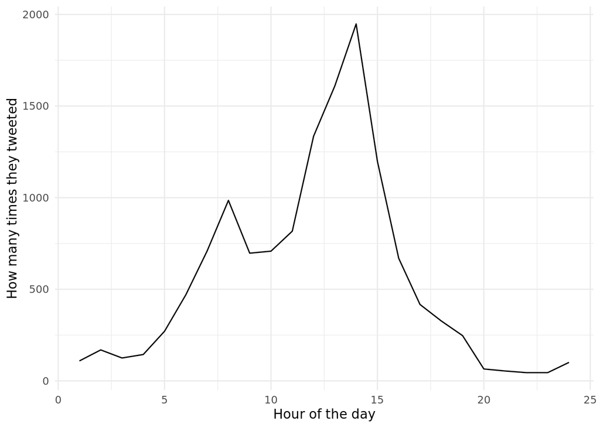

### By language

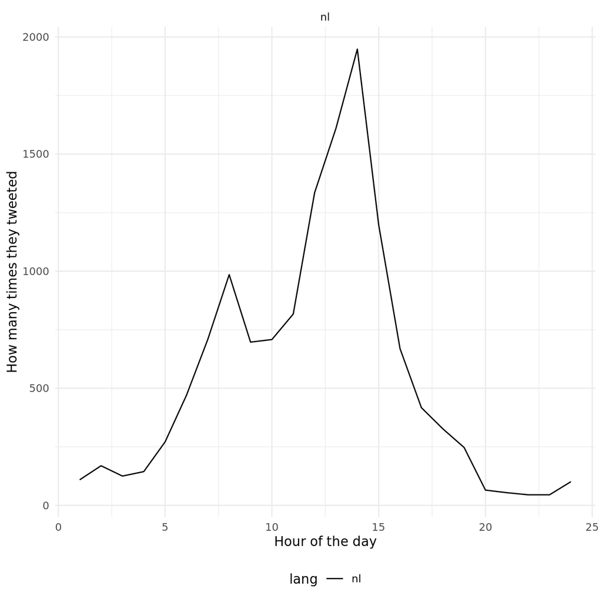

### By location

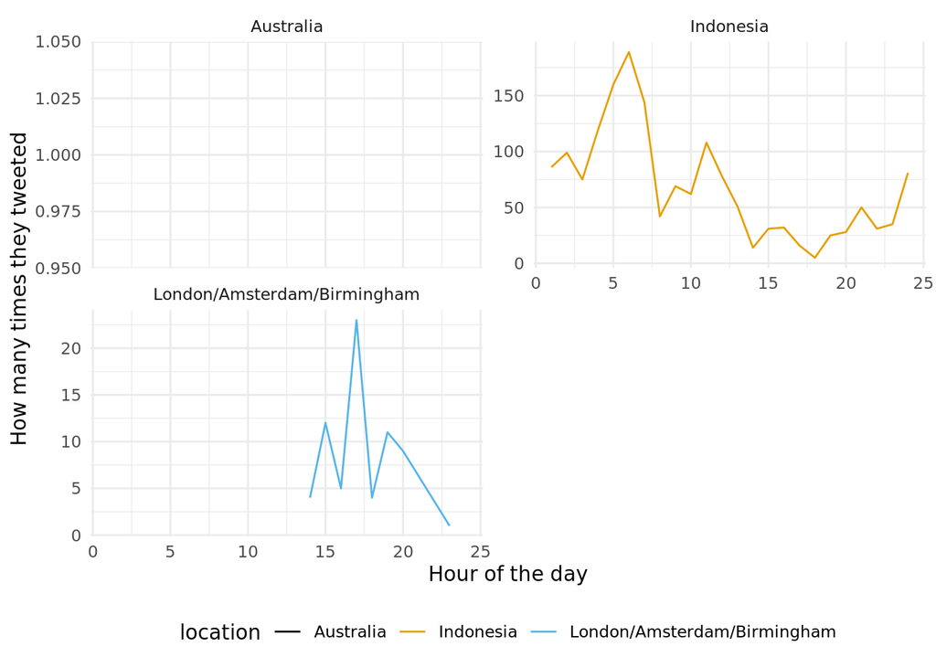

## Texts

|  | text | n |
| --- | --- | --- |
| 1 | laten we de voortzetting van Papua steunen voor het welzijn #Papua #papuaindonesia #PapuaMajuSejahtera #danaotsuspapua #dukungotsuspapua #untukapadanaotsus #otsuspapua | 10 |
| 2 | bijzondere autonomie moet worden geëvalueerd en voortgezet #Papua #papuaindonesia #PapuaMajuSejahtera #danaotsuspapua #dukungotsuspapua #untukapadanaotsus #otsuspapua | 9 |

## Networks

### Follower Network

[interactive chart not shown]

### Mentions Network

[interactive chart not shown]

### Retweet Network

[interactive chart not shown]